# The_EC349_Final_Markdown

2023-12-04

## Link to Github: https://github.com/Kuba-8/Data_Science_for_Econ

# Introduction

In this project I will attempt to predict the number of stars a given user rates a certain business on the review platform Yelp (“stars.x”), using a supervised machine learning model. The documentation for the variables in the dataset can be found on the Yelp website [1]. Within my data, a .x suffix for a variable corresponds to review data, and a .y corresponds to user data.

# Methodology Selection

The Data Science methodology I chose to apply during this project was the John Rallins’ Data Science Methodology. Given the nature of the task, both Phase 1 (the problem understanding) and Phase 2 (the data requirements and collection) were partially fixed from the outset. However, there was scope to vary the broad analytic approach and data preparation elements, both influenced by a growing data understanding of the project. I found myself periodically returning to the data preparation stage, editing the methods I had used to subdivide the data, given revised assumptions about the data and modelling process. For example, editing the variable selection after realising that some of the variables I had selected as possible features had too many missing values for meaningful imputation. Phase 3 of the methodology was deployed by evaluating various visualisations of the data to determine the best model given its characteristics. This was performed iteratively, where one model was substituted for another upon evaluation of its predictive performance in terms of means squared error (MSE).

# Dataset Selection and Merging

I began my project by choosing to anaylse each of the datasets available to me, to survey all the possible information at my disposal. The choice to convert each dataframe into the tibble format was made for increased compatibility with packages like ggplot2 and dplyr. Looking at the contents of each dataframe, I quickly decided that the three of the datasets (the user, business, and review data) had more intuitive relevance to the question at hand, though the other two may also contain some useful information and should therefore not be discounted.

A full-join combination was used to merge the three major datasets, in an effort to retain all the information contained within each one. However, datasets of varying size led to the presence of observations which did not align and therefore lacked vital information, such as the text of the review. These were consequently dropped from the resultant tibble.

Upon inspection of the data’s documentation [1], the decision to omit much of the tips-data and check-in data was made. The tip data refers to a shorter review type, that is not rated by stars and therefore these reviews are not directly relevant to those at hand. Though, the number of tip reviews that a business has, and number of check-ins (yelp user walk-ins) were added as proxies for business popularity with the help of a left-join, to avoid inundating the existing data with irrelevant information.

# Data Preparation

After dropping the observations with missing values generated in the data merging process, I then turned my attention to exploring the data, adjusting the relevant variable types, and using statistical and graphical tests to determine whether I should drop or keep variables. The figures below serve as examples of this, in which my visulisations were made using the ggplot2 package [2], [3]:

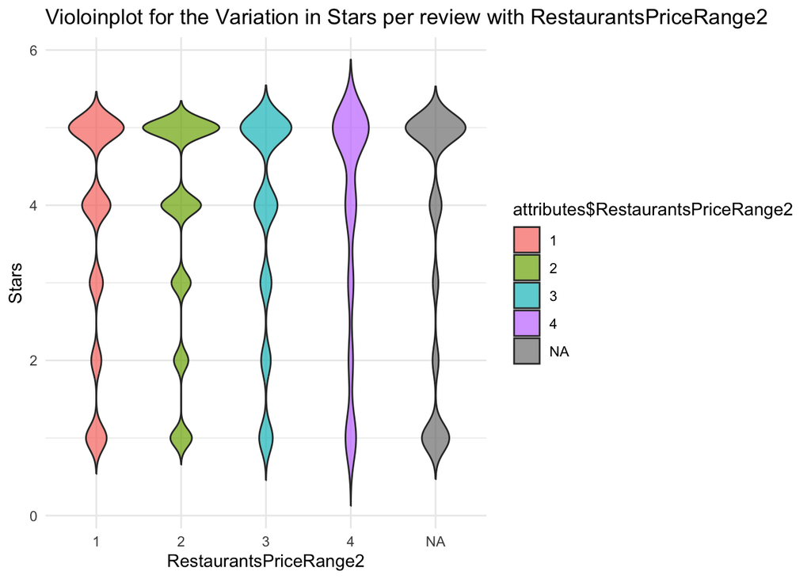

```r
# Graphical analysis

ggplot(final_tibble_2, aes(x = attributes$RestaurantsPriceRange2, y = stars.x, fill = attributes$RestaurantsPriceRange2)) +
  geom_violin(trim = FALSE, alpha = 0.7) +
  labs(title = "Violoinplot for the Variation in Stars per review with RestaurantsPriceRange2",
       x = "RestaurantsPriceRange2",
       y = "Stars") +
  theme_minimal()
```

```r
# Clear distributional differences are present

# Mathemtically

model_ranges <- lm(stars.x ~ attributes$RestaurantsPriceRange2, data = final_tibble_2)

summary(model_ranges)
```

```
##
## Call:
## lm(formula = stars.x ~ attributes$RestaurantsPriceRange2, data = final_tibble_2)
##
## Residuals:
##    Min     1Q Median     3Q    Max
## -2.851 -0.788  0.212  1.212  1.318
##
## Coefficients:
##                                    Estimate Std. Error t value Pr(>|t|)
## (Intercept)                        3.681758   0.006441 571.650  < 2e-16 ***
## attributes$RestaurantsPriceRange22 0.106211   0.007344  14.463  < 2e-16 ***
## attributes$RestaurantsPriceRange23 0.133505   0.012621  10.578  < 2e-16 ***
## attributes$RestaurantsPriceRange24 0.169119   0.032129   5.264 1.41e-07 ***
## ---
## Signif. codes:  0 '***' 0.001 '**' 0.01 '*' 0.05 '.' 0.1 ' ' 1
##
## Residual standard error: 1.426 on 231657 degrees of freedom
##   (48217 observations deleted due to missingness)
## Multiple R-squared:  0.001023,   Adjusted R-squared:  0.00101
## F-statistic: 79.08 on 3 and 231657 DF,  p-value: < 2.2e-16
```

```r
# Small, though statistically signficant relationship for all coefficients

# Distribution of stars.x with and without missing values being deleted


final_tibble_3 <- final_tibble_2 %>%
  filter(!is.na(attributes$RestaurantsPriceRange2))

missings_in_columns <- colSums(is.na(final_tibble_3))
print(missings_in_columns)
```

```
##                  review_id                    user_id
##                          0                          0
##                business_id                    stars.x
##                          0                          0
##                   useful.x                    funny.x
##                          0                          0
##                     cool.x                       text
##                          0                          0
##                       date                     name.x
##                          0                          0
##             review_count.x              yelping_since
##                          0                          0
##                   useful.y                    funny.y
##                          0                          0
##                     cool.y                      elite
##                          0                          0
##                    friends                       fans
##                          0                          0
##              average_stars             compliment_hot
##                          0                          0
##            compliment_more         compliment_profile
##                          0                          0
##            compliment_cute            compliment_list
##                          0                          0
##            compliment_note           compliment_plain
##                          0                          0
##            compliment_cool           compliment_funny
##                          0                          0
##          compliment_writer          compliment_photos
##                          0                          0
##                     name.y                    address
##                          0                          0
##                       city                      state
##                          0                          0
##                postal_code                   latitude
##                          0                          0
##                  longitude                    stars.y
##                          0                          0
##             review_count.y                    is_open
##                          0                          0
```

[output cut: 35 more lines]

```
##                     230592                     231257
##  RestaurantsCounterService                AgesAllowed
##                     231275                     231161
##        DietaryRestrictions                 categories
##                     231347                          0
##                     Monday                    Tuesday
##                      37018                      29030
##                  Wednesday                   Thursday
##                      17499                      12470
##                     Friday                   Saturday
##                      11281                      14178
##                     Sunday                  tip_count
##                      42579                       6033
##    checkin_timestamp_count
##                        879
```